# Tugas Pemodelan dan Diagnostik Model Arima

Fadly Mochammad Taufiq

2023-10-16

# 1 Persiapan bahan untuk analisis

## 1.1 Library

```r
library(tseries)
library(MASS)
library(TSA)
library(lmtest)
library(forecast)
```

## 1.2 Input Data

```r
data <- read.csv("https://raw.githubusercontent.com/imomenujung/MPDW/main/Pertemuan%201/Data%20Minyak.csv",sep=";")
data
```

```
##     Period Minyak_Goreng
## 1        1         15250
## 2        2         15250
## 3        3         15300
## 4        4         15250
## 5        5         15300
## 6        6         15350
## 7        7         15250
## 8        8         15300
## 9        9         15600
## 10      10         15650
## 11      11         15900
## 12      12         15950
## 13      13         16200
## 14      14         16200
```

[output cut: 106 more lines]

Data tersebut merupakan data perkembangan minyak goreng di kota Bogor tiap minggu dari bulan Mei 2021 - Agustus 2023 (satuan Rupiah)

## 1.3 Partisi Data

```r
data.ts <- ts(data$Minyak_Goreng)
data_train <- ts(data$Minyak_Goreng[1:75])
data_test <- ts(data$Minyak_Goreng[76:120])
data_train
```

```
## Time Series:
## Start = 1
## End = 75
## Frequency = 1
##  [1] 15250 15250 15300 15250 15300 15350 15250 15300 15600 15650 15900 15950
## [13] 16200 16200 16250 16600 16800 16800 16800 16850 16900 17150 17550 17750
## [25] 17800 18300 18750 19200 19400 19400 19750 20100 20200 20350 20500 20700
## [37] 20700 20700 20150 18250 17600 17100 17100 16850 16850 19600 23300 23850
## [49] 23400 23400 23500 23750 23150 22900 22100 22100 21850 21700 21350 20850
## [61] 20700 19600 20700 20450 19350 19000 18800 18250 18100 17750 17750 17650
## [73] 17650 17700 17650
```

```r
data_test
```

```
## Time Series:
## Start = 1
## End = 45
## Frequency = 1
##  [1] 17800 17850 17900 17950 18600 18850 18750 18650 18650 18650 18650 18650
## [13] 18650 18650 18650 18650 18650 18650 18650 18650 18650 18750 18750 18750
## [25] 18750 18750 18750 18750 18750 18750 18750 18750 18750 18750 18750 18750
## [37] 18750 18750 18750 18700 18700 18600 18600 18600 18500
```

# 2 Eksplorasi Data

## 2.1 Visualisasi data

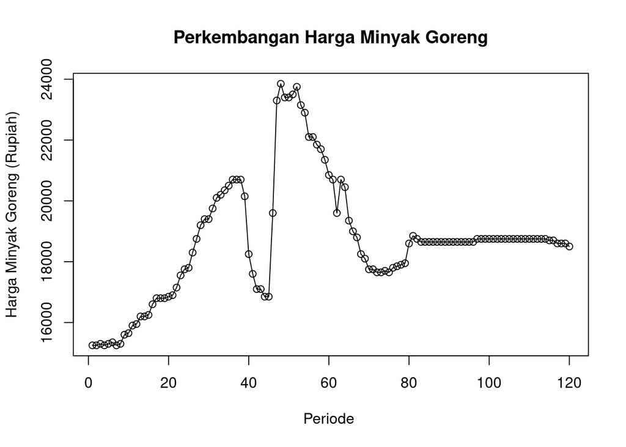

```r
# Plot Data Keseluruhan
ts.plot(data.ts, xlab="Periode ", ylab="Harga Minyak Goreng (Rupiah)",
        main = "Perkembangan Harga Minyak Goreng")
points(data.ts)
```

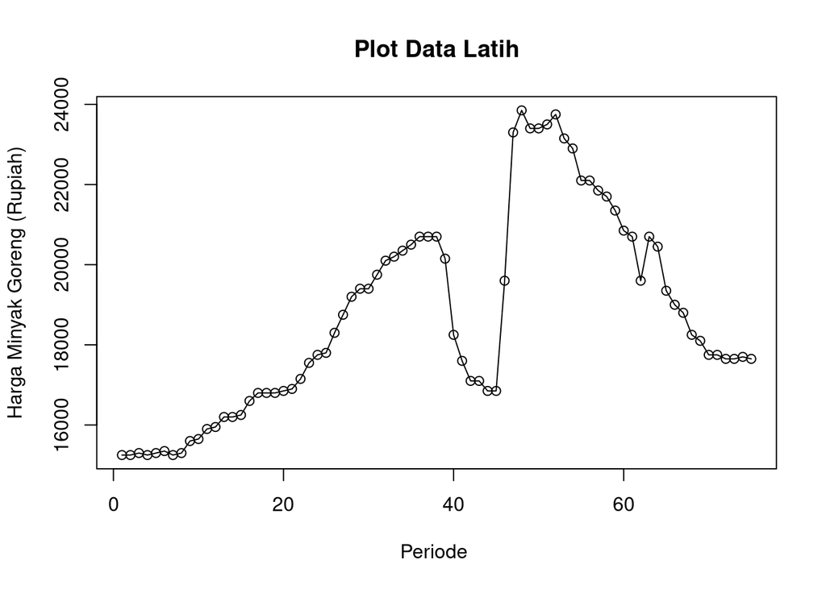

```r
# plot data latih
ts.plot(data_train, xlab="Periode ", ylab="Harga Minyak Goreng (Rupiah)",
        main = "Plot Data Latih")
points(data_train)
```

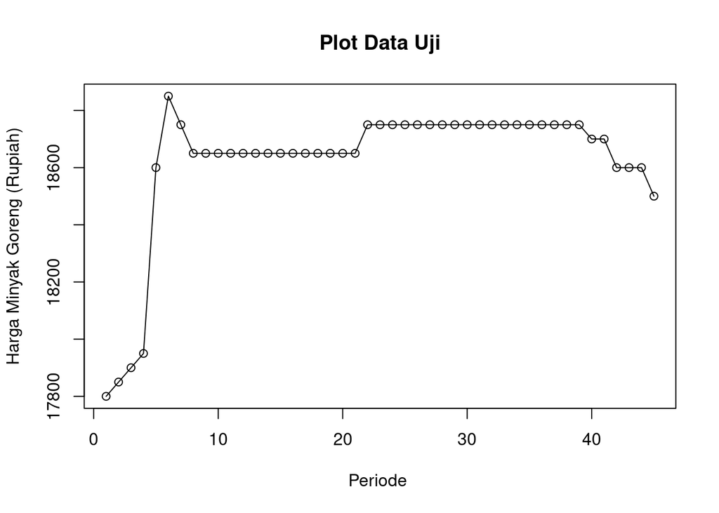

```r
# Plot data Uji
ts.plot(data_test, xlab="Periode ", ylab="Harga Minyak Goreng (Rupiah)",
        main = "Plot Data Uji")
points(data_test)
```

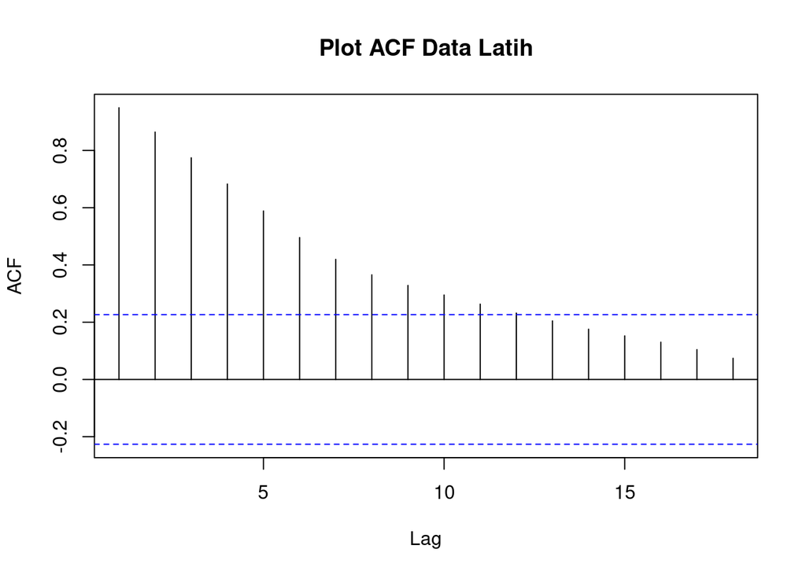

```r
# plot ACF data latih
acf(data_train, main = "Plot ACF Data Latih")
```

Berdasarkan plot ACF, terlihat bahwa plot ACF pada data tersebut menurun secara perlahan (*tails off slowly*) yang menandakan data tidak stasioner dalam rataan

## 2.2 Uji ADF Data Latih

```r
adf.test(data_train)
```

```
##
##  Augmented Dickey-Fuller Test
##
## data:  data_train
## Dickey-Fuller = -2.037, Lag order = 4, p-value = 0.5604
## alternative hypothesis: stationary
```

H_0 : Data tidak stasioner dalam rataan H_1 : Data stasioner dalam rataan

P val sebesar **0.5604** lebih besar dari taraf 5%, sehingga tak tolak H0, cukup bukti untuk mengatakan data tidak stasioner dalam rataan

## 2.3 Boxcox Data Latih

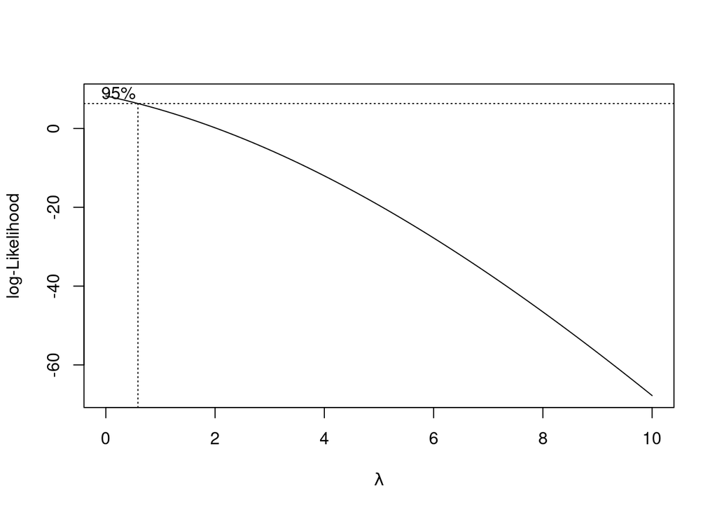

```r
#Plot Boxcox
index <- seq(1:length(data_train))
bc = boxcox(data_train~index, lambda = seq(0,10,by=1))
```

```r
#Nilai Lambda
lambda <- bc$x[which.max(bc$y)]
lambda
```

```
## [1] 0
```

```r
#SK
bc$x[bc$y > max(bc$y) - 1/2 * qchisq(.95,1)]
```

[output not shown]

Plot Boxcox menunjukkan nilai rounded value optimum sebesar **0** dan pada selang kepercayaan 95% nilai memiliki batas bawah **0** dan batas atas **0.5050505**. Selang tersebut tidak memuat nilai satu sehingga dapat dikatakan bahwa data bangkitan tidak stasioner dalam ragam.

# 3 Penanganan Tidak Stasioner

## 3.1 Eksplorasi

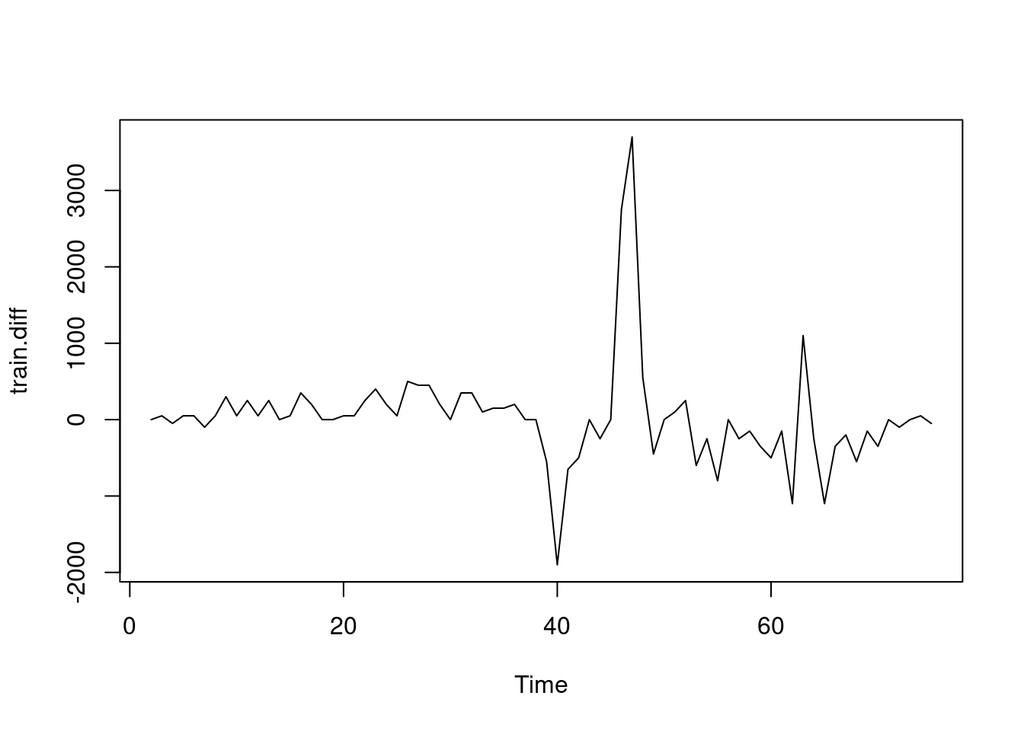

```r
train.diff<-diff(data_train,differences = 1)
plot.ts(train.diff)
```

berdasarkan plot data deret waktu, terlihat bahwa di awal data sudah stasioner dalam rataan ditandai dengan data bergerak pada nilai tengah tertentu namun dipertengahan terlihat data kurang stasioner

## 3.2 ACF dan Uji ADF

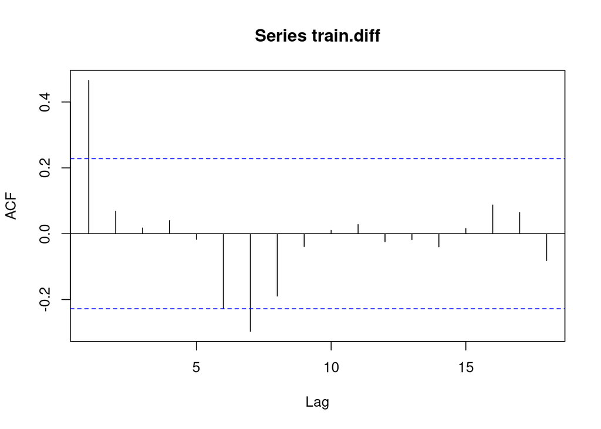

```r
acf(train.diff)
```

```r
adf.test(train.diff)
```

```
##
##  Augmented Dickey-Fuller Test
##
## data:  train.diff
## Dickey-Fuller = -3.5193, Lag order = 4, p-value = 0.04637
## alternative hypothesis: stationary
```

Hasil ACF : plot ACF cenderung *cuts off* pada lag ke 1 dan 7. Sehingga jika plot PACF dianggap *tails of*, maka model tentatifnya adalah ARIMA(0,1,1) / ARIMA(0,1,7).

Hasil ADF : H_0 : Data tidak stasioner dalam rataan H_1 : Data stasioner dalam rataan P val sebesar **0.04637** lebih kecil dari taraf 5%, sehingga tolak H0, sehingga bisa dikatakan data cenderung stasioner dalam rataan.

## 3.3 PACF

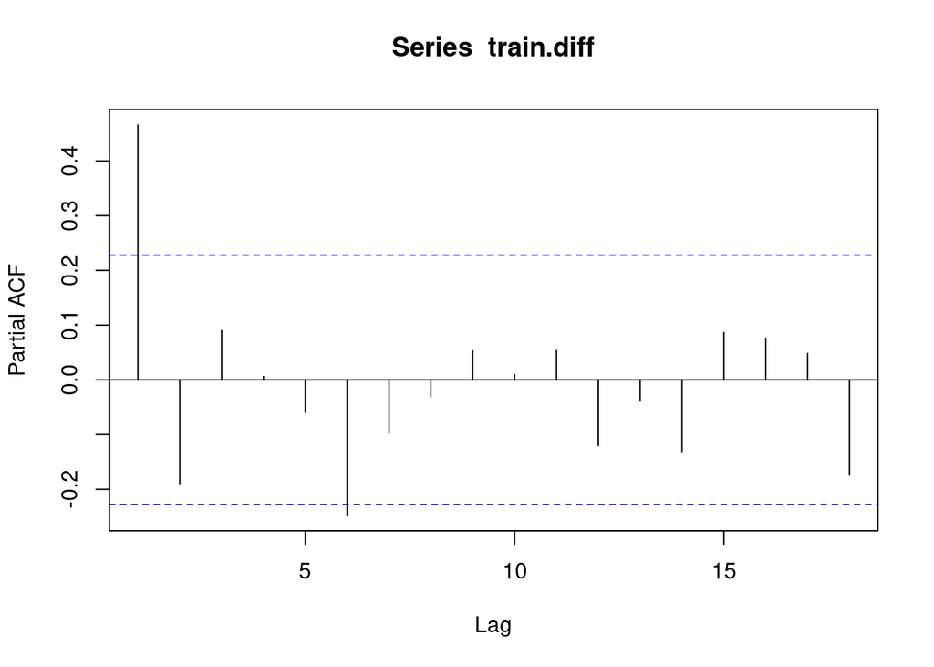

```r
pacf(train.diff)
```

plot PACF cenderung *cuts off* pada lag ke 1 dan 6, sehingga jika plot ACF dianggap tails of, maka model tentatifnya adalah ARIMA(1,1,0) / ARIMA(6,1,0).

## 3.4 EACF

```r
eacf(train.diff)
```

```
## AR/MA
##   0 1 2 3 4 5 6 7 8 9 10 11 12 13
## 0 x o o o o o x o o o o  o  o  o
## 1 x o o o o o o o o o o  o  o  o
## 2 x o o o o o o o o o o  o  o  o
## 3 o o o o o o o o o o o  o  o  o
## 4 o o o o o o o o o o o  o  o  o
## 5 o o x x o o o o o o o  o  o  o
## 6 x o o o o o o o o o o  o  o  o
## 7 x o o o o x o o o o o  o  o  o
```

model tentatif yang terbentuk adalah ARIMA(0,1,1), ARIMA(0,1,2), ARIMA(0,1,1), ARIMA(1,1,1), ARIMA(2,1,1),ARIMA(3,1,0) dan masih banyak lagi.

# 4 Pemodelan ARIMA

```r
#0,1,1
model1<-Arima(train.diff, order=c(0,1,1),method="ML")
summary(model1) #AIC=1164.33
```

```
## Series: train.diff
## ARIMA(0,1,1)
##
## Coefficients:
##           ma1
##       -0.4526
## s.e.   0.1928
##
## sigma^2 = 473381:  log likelihood = -580.16
## AIC=1164.33   AICc=1164.5   BIC=1168.91
##
## Training set error measures:
##                      ME     RMSE      MAE MPE MAPE      MASE      ACF1
## Training set -0.7592028 678.6652 370.7024 NaN  Inf 0.9157791 0.1545059
```

```r
coeftest(model1)
```

```
##
## z test of coefficients:
##
##     Estimate Std. Error z value Pr(>|z|)
## ma1 -0.45257    0.19278 -2.3476  0.01889 *
## ---
## Signif. codes:  0 '***' 0.001 '**' 0.01 '*' 0.05 '.' 0.1 ' ' 1
```

```r
#0,1,7
model2<-Arima(train.diff, order=c(0,1,7),method="ML")
summary(model2) #AIC=1156.22
```

```
## Series: train.diff
## ARIMA(0,1,7)
##
## Coefficients:
##           ma1      ma2     ma3      ma4     ma5      ma6     ma7
##       -0.4133  -0.4439  0.0015  -0.0086  0.0703  -0.2327  0.0267
## s.e.   0.1328   0.1381  0.1552   0.1275  0.1443   0.1548  0.1268
##
## sigma^2 = 375221:  log likelihood = -570.11
## AIC=1156.22   AICc=1158.47   BIC=1174.55
##
## Training set error measures:
##                     ME     RMSE      MAE MPE MAPE      MASE         ACF1
## Training set -23.51185 578.4952 347.6099 NaN  Inf 0.8587318 -0.004042448
```

```r
coeftest(model2)
```

```
##
## z test of coefficients:
##
##       Estimate Std. Error z value Pr(>|z|)
## ma1 -0.4132820  0.1328478 -3.1109 0.001865 **
## ma2 -0.4439372  0.1381383 -3.2137 0.001310 **
## ma3  0.0014808  0.1551523  0.0095 0.992385
## ma4 -0.0085904  0.1275228 -0.0674 0.946292
## ma5  0.0702582  0.1442531  0.4870 0.626224
## ma6 -0.2326509  0.1548242 -1.5027 0.132922
## ma7  0.0267266  0.1267949  0.2108 0.833054
## ---
## Signif. codes:  0 '***' 0.001 '**' 0.01 '*' 0.05 '.' 0.1 ' ' 1
```

```r
#1,1,0
model3<-Arima(train.diff, order=c(1,1,0),method="ML")
summary(model3) #AIC=1167.5
```

```
## Series: train.diff
## ARIMA(1,1,0)
##
## Coefficients:
##           ar1
##       -0.1262
## s.e.   0.1153
##
## sigma^2 = 495884:  log likelihood = -581.75
## AIC=1167.5   AICc=1167.67   BIC=1172.08
##
## Training set error measures:
##                      ME     RMSE      MAE MPE MAPE      MASE        ACF1
## Training set -0.5957977 694.6088 393.7888 NaN  Inf 0.9728115 -0.04546805
```

```r
coeftest(model3)
```

```
##
## z test of coefficients:
##
##     Estimate Std. Error z value Pr(>|z|)
## ar1 -0.12622    0.11530 -1.0947   0.2737
```

```r
#6,1,0
model4<-Arima(train.diff, order=c(6,1,0),method="ML")
summary(model4) #AIC=1163.6
```

```
## Series: train.diff
## ARIMA(6,1,0)
##
## Coefficients:
##           ar1      ar2      ar3      ar4     ar5      ar6
##       -0.2444  -0.4088  -0.2125  -0.1360  0.0251  -0.1146
## s.e.   0.1159   0.1184   0.1265   0.1253  0.1161   0.1120
##
## sigma^2 = 437541:  log likelihood = -574.8
## AIC=1163.6   AICc=1165.32   BIC=1179.63
##
## Training set error measures:
##                      ME     RMSE      MAE MPE MAPE     MASE        ACF1
## Training set -0.9276658 629.4062 373.0833 NaN  Inf 0.921661 -0.02302309
```

```r
coeftest(model4)
```

```
##
## z test of coefficients:
##
##      Estimate Std. Error z value  Pr(>|z|)
## ar1 -0.244362   0.115939 -2.1077 0.0350594 *
## ar2 -0.408766   0.118399 -3.4525 0.0005555 ***
## ar3 -0.212490   0.126494 -1.6798 0.0929884 .
## ar4 -0.135991   0.125287 -1.0854 0.2777289
## ar5  0.025073   0.116080  0.2160 0.8289928
## ar6 -0.114585   0.111982 -1.0232 0.3061911
## ---
## Signif. codes:  0 '***' 0.001 '**' 0.01 '*' 0.05 '.' 0.1 ' ' 1
```

```r
#1,1,1
model5<-Arima(train.diff, order=c(1,1,1),method="ML")
summary(model5) #AIC=1151.31
```

```
## Series: train.diff
## ARIMA(1,1,1)
##
## Coefficients:
##          ar1      ma1
##       0.4793  -1.0000
## s.e.  0.1044   0.0531
##
## sigma^2 = 374792:  log likelihood = -572.66
## AIC=1151.31   AICc=1151.66   BIC=1158.18
##
## Training set error measures:
##                     ME     RMSE   MAE MPE MAPE      MASE       ACF1
## Training set -29.08648 599.6647 325.9 NaN  Inf 0.8050999 0.07573934
```

```r
coeftest(model5)
```

```
##
## z test of coefficients:
##
##      Estimate Std. Error  z value  Pr(>|z|)
## ar1  0.479301   0.104387   4.5916 4.399e-06 ***
## ma1 -0.999996   0.053085 -18.8375 < 2.2e-16 ***
## ---
## Signif. codes:  0 '***' 0.001 '**' 0.01 '*' 0.05 '.' 0.1 ' ' 1
```

```r
#2,1,1
model6<-Arima(train.diff, order=c(2,1,1),method="ML")
summary(model6) #AIC=1151.02
```

```
## Series: train.diff
## ARIMA(2,1,1)
##
## Coefficients:
##          ar1      ar2      ma1
##       0.5580  -0.1742  -1.0000
## s.e.  0.1147   0.1139   0.0954
##
## sigma^2 = 366509:  log likelihood = -571.51
## AIC=1151.02   AICc=1151.61   BIC=1160.19
##
## Training set error measures:
##                    ME     RMSE      MAE MPE MAPE      MASE        ACF1
## Training set -35.0189 588.8106 330.4923 NaN  Inf 0.8164446 0.009076378
```

```r
coeftest(model6)
```

```
##
## z test of coefficients:
##
##      Estimate Std. Error  z value  Pr(>|z|)
## ar1  0.558020   0.114706   4.8648 1.146e-06 ***
## ar2 -0.174244   0.113883  -1.5300     0.126
## ma1 -1.000000   0.095351 -10.4876 < 2.2e-16 ***
## ---
## Signif. codes:  0 '***' 0.001 '**' 0.01 '*' 0.05 '.' 0.1 ' ' 1
```

```r
#3,1,0
model7<-Arima(train.diff, order=c(3,1,0),method="ML")
summary(model7) #AIC=1159.68
```

```
## Series: train.diff
## ARIMA(3,1,0)
##
## Coefficients:
##           ar1      ar2      ar3
##       -0.2367  -0.3703  -0.1877
## s.e.   0.1145   0.1077   0.1125
##
## sigma^2 = 431687:  log likelihood = -575.84
## AIC=1159.68   AICc=1160.27   BIC=1168.84
##
## Training set error measures:
##                      ME     RMSE      MAE MPE MAPE      MASE        ACF1
## Training set -0.7628783 639.0246 383.1696 NaN  Inf 0.9465781 -0.02346226
```

```r
coeftest(model7)
```

```
##
## z test of coefficients:
##
##     Estimate Std. Error z value  Pr(>|z|)
## ar1 -0.23667    0.11451 -2.0668 0.0387576 *
## ar2 -0.37034    0.10769 -3.4389 0.0005841 ***
## ar3 -0.18771    0.11246 -1.6692 0.0950772 .
## ---
## Signif. codes:  0 '***' 0.001 '**' 0.01 '*' 0.05 '.' 0.1 ' ' 1
```

# 5 Analisis Sisaan

Model terbaik hasil identifikasi kemudian dicek asumsi sisaannya. Sisaan model ARIMA harus memenuhi asumsi normalitas, kebebasan, dan kehomogenan ragam. Diagnostik model dilakukan secara eksplorasi dan uji formal.

## 5.1 Eksplorasi sisaan

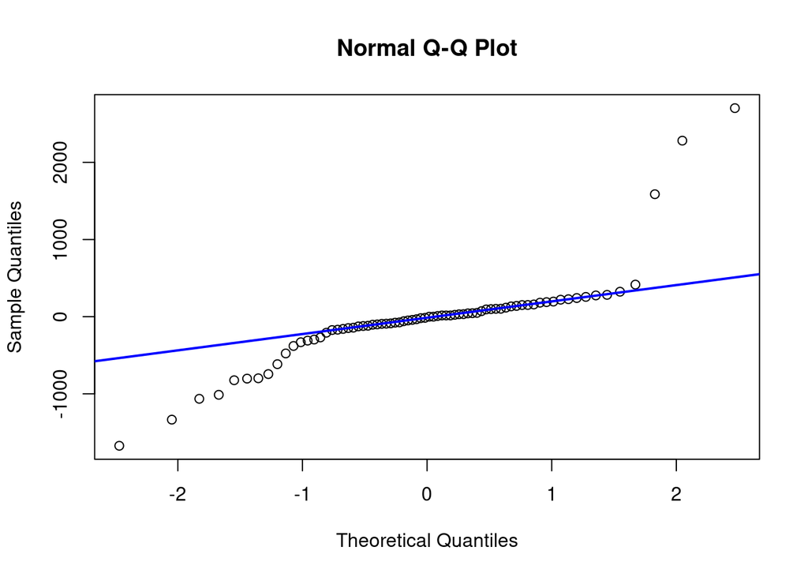

```r
sisaan.da <- model5$residuals
par(mfrow=c(1,1))
qqnorm(sisaan.da)
qqline(sisaan.da, col = "blue", lwd = 2)
```

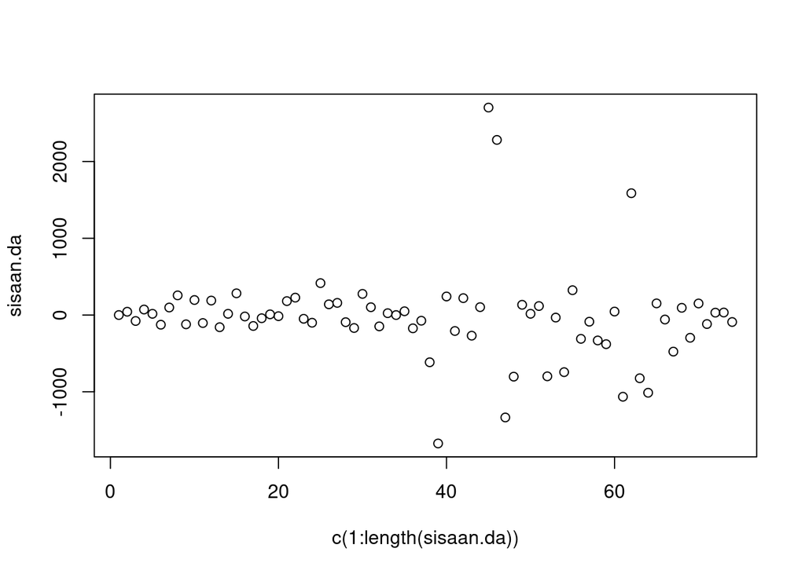

```r
plot(c(1:length(sisaan.da)),sisaan.da)
```

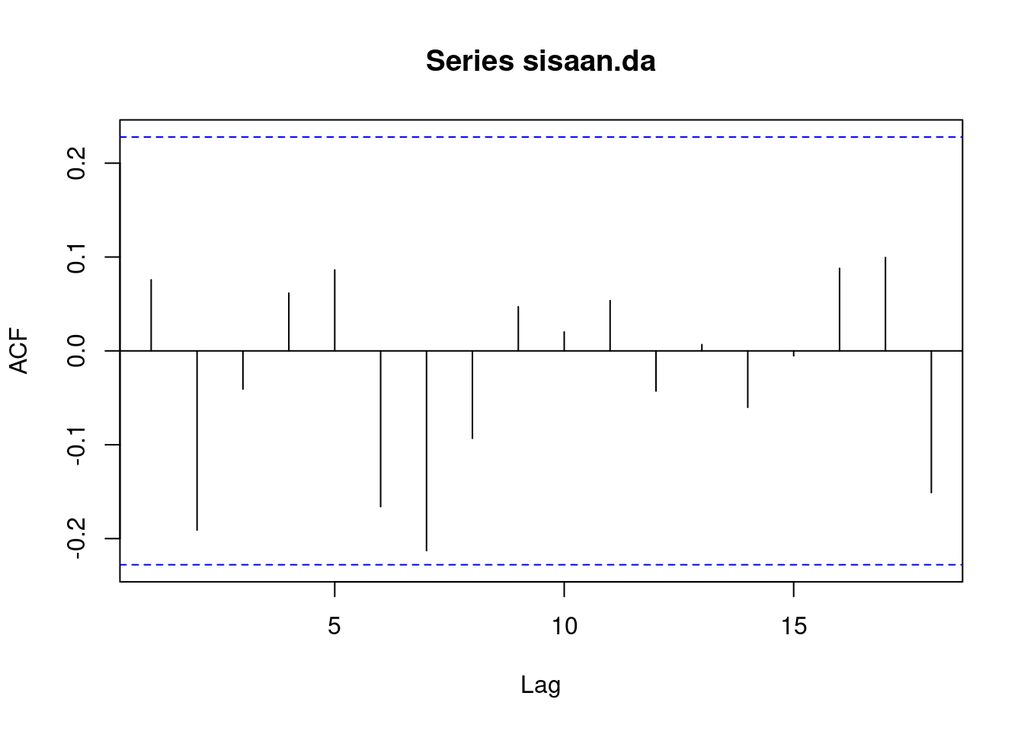

```r
acf(sisaan.da)
```

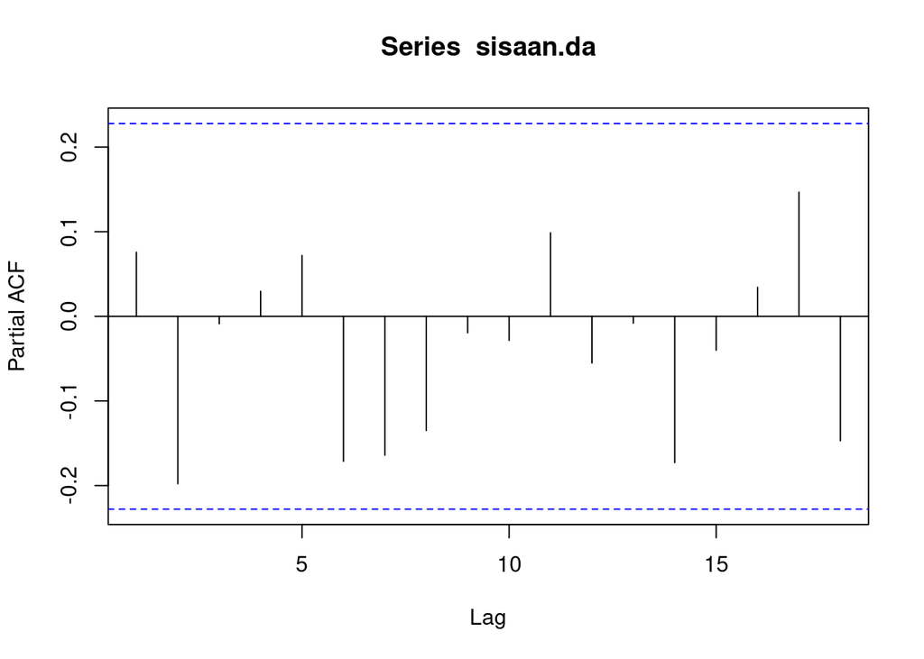

```r
pacf(sisaan.da)
```

Berdasarkan Eksplorasi terlihat bahwa sisaan tidak menyebar normal dan sisaan saling bebas linear, dan berdasarkan ACF dan PACF pada semua lag terlihat tidak ada nilai yang keluar dari batas.

## 5.2 Uji Kenormalan

```r
ks.test(sisaan.da,"pnorm")  #tak tolak H0 > sisaan menyebar normal
```

```
##
##  One-sample Kolmogorov-Smirnov test
##
## data:  sisaan.da
## D = 0.5, p-value = 1.332e-15
## alternative hypothesis: two-sided
```

H0: Sisaan menyebar normal H1: Sisaan tidak menyebar normal

Berdasarkan uji Kolmogrov Smirnov, didapat p-value sebesar **1.332e-15* yang kurang dari taraf nyata 5% sehingga tolak H0. dan menandakan bahwa sisaan tidak menyebar normal.

## 5.3 Uji Kebebasan (Identifikasi Korelasi)

```r
Box.test(sisaan.da, type = "Ljung")  #tak tolak H0 > sisaan saling bebas
```

```
##
##  Box-Ljung test
##
## data:  sisaan.da
## X-squared = 0.44194, df = 1, p-value = 0.5062
```

H0 : Sisaan saling bebas H1 : Sisaan tidak saling bebas Berdasarkan uji Ljung-Box , didapat p-value sebesar **0.5062** yang lebih besar dari taraf nyata 5% sehingga tak tolak H0. Hal ini menandakan bahwa sisaan saling bebas.

## 5.4 Uji Kehomogenan ragam Sisaan

```r
Box.test((sisaan.da)^2, type = "Ljung")  #tak tolak H0 > sisaan homogen
```

```
##
##  Box-Ljung test
##
## data:  (sisaan.da)^2
## X-squared = 18.615, df = 1, p-value = 1.599e-05
```

H0 : Ragam sisaan homogen H1 : Ragam sisaan tidak homogen

## 5.5 Uji Nilai tengah sisaan sama dengan nol

```r
t.test(sisaan.da, mu = 0, conf.level = 0.95)  #tak tolak h0 > nilai tengah sisaan sama dengan 0
```

```
##
##  One Sample t-test
##
## data:  sisaan.da
## t = -0.41491, df = 73, p-value = 0.6794
## alternative hypothesis: true mean is not equal to 0
## 95 percent confidence interval:
##  -168.8012  110.6283
## sample estimates:
## mean of x
## -29.08648
```

H0 : nilai tengah sisaan sama dengan 0 H1 : nilai tengah sisaan tidak sama dengan 0

Berdasarkan uji-t, didapat p-value sebesar **0.6794** yang lebih besar dari taraf nyata 5% sehingga tak tolak H0 menandakan bahwa nilai tengah sisaan sama dengan nol.

# 6 Peramalan

Berikut peramalan untuk 45 periode kedepan

```r
ramalan.da <- forecast(model5, h = 45)
ramalan.da
```

```
##     Point Forecast     Lo 80    Hi 80     Lo 95    Hi 95
##  76      -7.803409 -797.5266 781.9198 -1215.581 1199.974
##  77      12.421443 -867.7584 892.6013 -1333.697 1358.540
##  78      22.115228 -879.6314 923.8619 -1356.987 1401.218
##  79      26.761465 -880.8524 934.3754 -1361.314 1414.837
##  80      28.988409 -880.4391 938.4160 -1361.861 1419.838
##  81      30.055785 -880.0135 940.1251 -1361.775 1421.887
##  82      30.567379 -879.7574 940.8922 -1361.654 1422.789
##  83      30.812586 -879.6227 941.2478 -1361.578 1423.203
##  84      30.930114 -879.5554 941.4156 -1361.537 1423.397
##  85      30.986445 -879.5225 941.4954 -1361.517 1423.490
##  86      31.013445 -879.5065 941.5334 -1361.507 1423.534
##  87      31.026386 -879.4989 941.5517 -1361.502 1423.555
##  88      31.032588 -879.4952 941.5604 -1361.500 1423.565
##  89      31.035561 -879.4934 941.5646 -1361.498 1423.570
```

[output cut: 31 more lines]

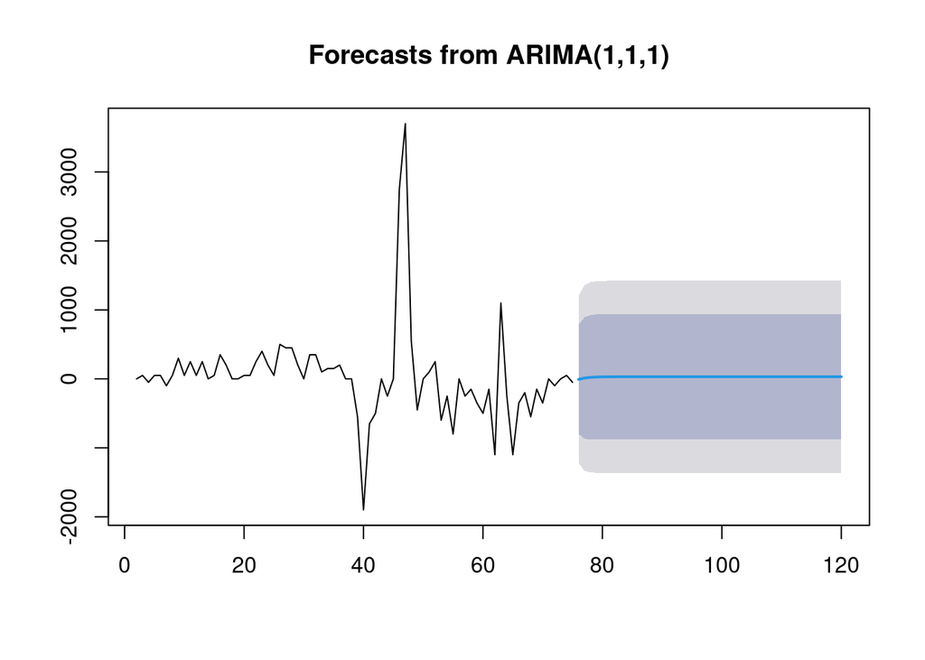

```r
data.ramalan.da <- ramalan.da$mean
plot(ramalan.da)
```

## Eksplorasi data hasil peramalan

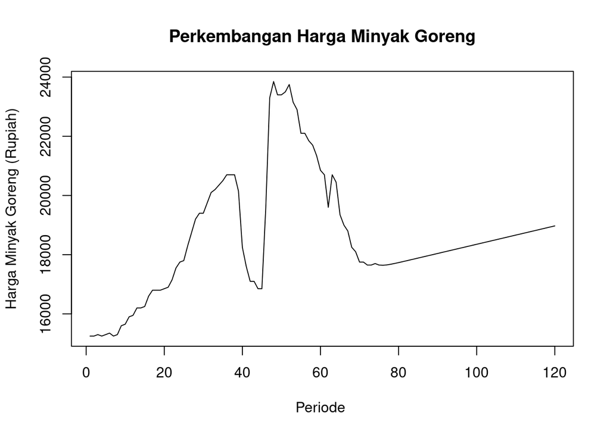

```r
pt_1 <- data_train[length(data_train)] #nilai akhir data latih
hasil.forc.Diff <- data.ramalan.da
hasil <- diffinv(hasil.forc.Diff, differences = 1) + pt_1
#has.1 sama hasilnta dengan: cumsum(c(pt_1,hasil.forc.Diff))
ts.plot(data_train,hasil,xlab="Periode ", ylab="Harga Minyak Goreng (Rupiah)",
        main = "Perkembangan Harga Minyak Goreng")
```

Data peramalan menunjukkan harga minyak akan selalu naik perlahan

## 6.1 Perbandingan data Uji dengan data hasil peramalan

```r
perbandingan.da<-matrix(data=c(head(data_test, n=45), hasil[-1]),
                        nrow = 45, ncol = 2)
colnames(perbandingan.da)<-c("Aktual","Hasil Forecast")
perbandingan.da
```

```
##       Aktual Hasil Forecast
##  [1,]  17800       17642.20
##  [2,]  17850       17654.62
##  [3,]  17900       17676.73
##  [4,]  17950       17703.49
##  [5,]  18600       17732.48
##  [6,]  18850       17762.54
##  [7,]  18750       17793.11
##  [8,]  18650       17823.92
##  [9,]  18650       17854.85
## [10,]  18650       17885.84
## [11,]  18650       17916.85
## [12,]  18650       17947.88
## [13,]  18650       17978.91
## [14,]  18650       18009.94
```

[output cut: 31 more lines]

```r
selisih <- perbandingan.da[ ,1] -perbandingan.da[ ,2]
selisih <- as.matrix(abs(selisih))
colnames(selisih)<-c("Selisih antara Aktual dengan Forecast")
summary(selisih)
```

```
##  Selisih antara Aktual dengan Forecast
##  Min.   :   4.86
##  1st Qu.: 195.38
##  Median : 367.60
##  Mean   : 407.32
##  3rd Qu.: 577.98
##  Max.   :1087.46
```

Dari Hasil antara data Aktual dengan data peramalan didapatkan rata-rata selisih sebesar **407.32 rupiah** dengan selisih terkecil sama dengan **4.86 rupiah** dan selisih terbesar sebesar **1087 rupiah**

## 6.2 Tingkat Akurasi

```r
accuracy(ts(hasil[-1]), head(data_test, n=45))
```

```
##                ME     RMSE      MAE      MPE     MAPE      ACF1 Theil's U
## Test set 331.4108 486.5843 407.3198 1.776221 2.184527 0.8928398  4.292191
```